# Can Money Buy Happiness?

## Background

We often hear many varying phrases that describe whether money can or can not buy happiness. Those on the poor end hope that money isn’t everything, whereas those that are richer we might suppose believe that money is everything. My study today is based off of data from the GSS , the General Social Survey, which is a survey given out to many Americans to identify the different concerns and development of the people in the United States.

Uisng this data, I will perform a Permutated Chi-Squared Test to find the results. Our question posed will be whether or not money has had an impact on people’s happiness. Or in other words; can money buy happiness?

My hypotheses will be the following:
$$H_0: \text{A person's happiness and their income are independent of each other}$$

$$H_a: \text{A person's happiness and their income are associated}$$

## Data

```r
datatable(hapgss,options = list(lengthMenu=c(5,10,30,100)))
```

|  | god | happy | coninc | money | gladness |
| --- | --- | --- | --- | --- | --- |
| 1 | 5 | 1 | 178712.4649 | $100,000 or more | Very Happy |
| 2 | 5 | 1 | 178712.4649 | $100,000 or more | Very Happy |
| 3 | 3 | 2 | 91920 | $50,000-$100,000 | Pretty Happy |
| 4 | 3 | 1 | 107240 | $100,000 or more | Very Happy |
| 5 | 6 | 1 | 42130 | $25,000-$50,000 | Very Happy |
| 6 | 5 | 1 | 21065 | $25,000 or less | Very Happy |
| 7 | 6 | 2 | 24895 | $25,000 or less | Pretty Happy |
| 8 | 6 | 2 | 4213 | $25,000 or less | Pretty Happy |
| 9 | 6 | 3 | 383 | $25,000 or less | Not Happy |
| 10 | 3 | 2 | 24895 | $25,000 or less | Pretty Happy |

[output cut: 1954 more lines]

## Analysis

I’ve created the following barplot to effectively decribe the spread of the data.

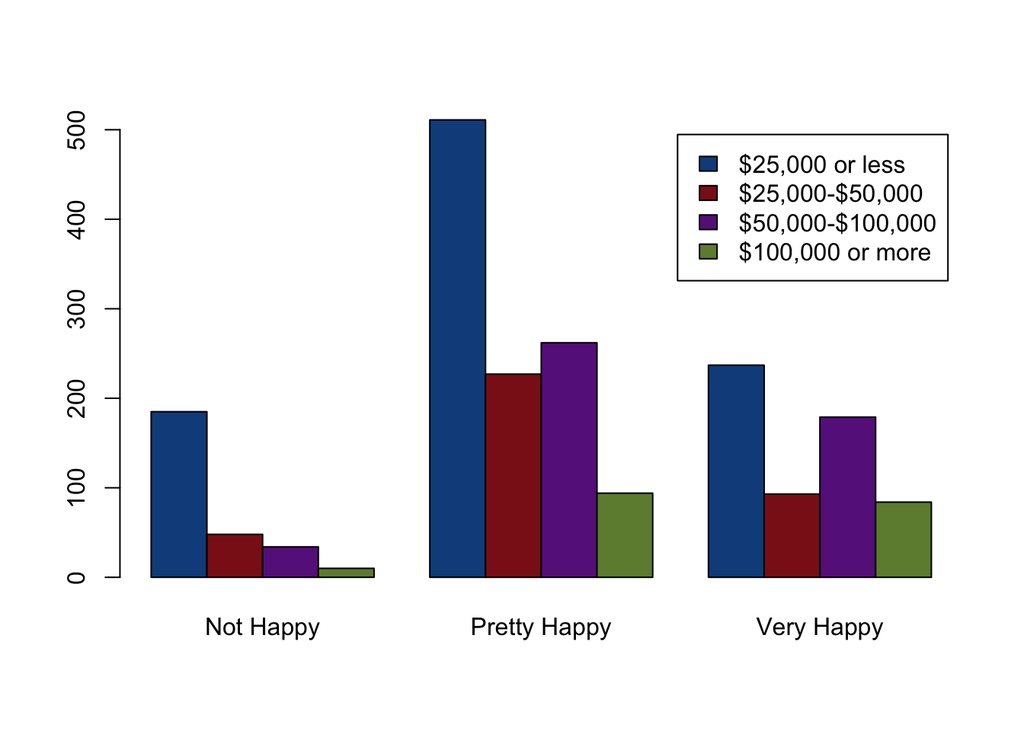

```r
barplot(happy, beside=TRUE, legend.text = TRUE, col=c('dodgerblue4','firebrick4','darkorchid4','darkolivegreen4'))
```

According to what we see in the plot, it does appear that there is a difference between the levels of happiness for those that make more than $100,000. After viewing this and other potential trend, this following histogram will represent how extreme our results are based off of a permutations test.

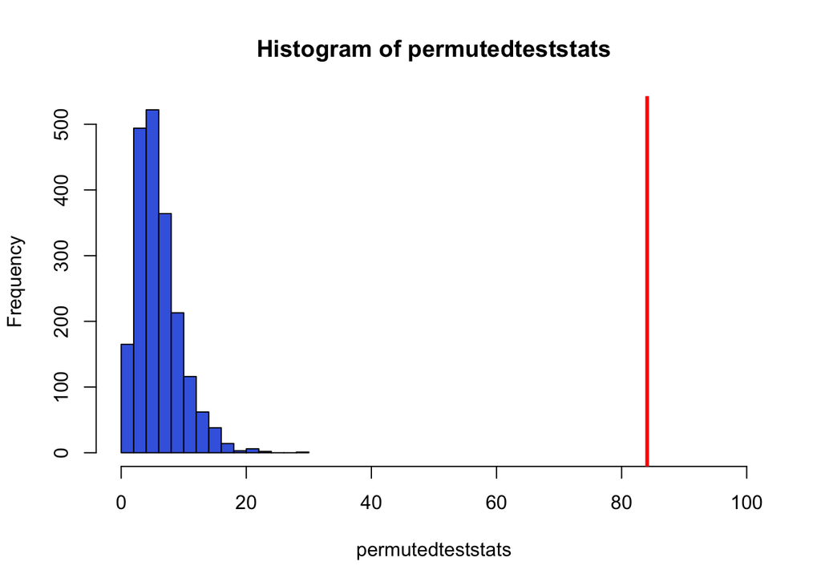

```r
set.seed(121)
myTest<-chisq.test(happy)
obsteststat<-myTest$statistic

N <- 2000
permutedteststats<-rep(NA, N)
for (i in 1:N) {
  permutedData<-table(hapgss$money, sample(hapgss$gladness))
  permutedtest<-chisq.test(permutedData)
  permutedteststats[i]<-permutedtest$statistic
}


hist(permutedteststats, xlim=c(0,100), col='royalblue')
abline(v = obsteststat, col = "red", lwd = 3)
```

And below I have placed a table decribing the results of this permuted test.

`Permuted Test Results`

| X-squared | p-value |
| --- | --- |
| 84.08345 | 0 |